# Regression

### Jimmy Azar

In this lab, we will explore linear regression and the quality of regression. We will also apply a nonlinear regression method, namely kernel regression.

## Linear Regression

In this section, we consider simple linear regression which consists of fitting a linear function to the data. The main assumption here is that the data comes from a linear model given by:

$$y = \beta_0 + \beta_1 x + \epsilon$$

Thereafter, we try to estimate the model with the regression line:

$$\widehat{y} = \beta_0 + \beta_1 x$$

The parameters are usually estimated using the least squares method which minimizes the sum of squares difference between the estimated values and the actual observed data $[y_1,y_2,...,y_n]$:

$$J_{LS} = \sum_i \epsilon_i^2 = \sum_i (y_i -\beta_0-\beta_1 x_i)^2$$

The parameter estimates may be obtained analytically by setting the partial derivatives with respect to the offset and the other coefficients of the above equation to zero and solving to arrive at:

$$\widehat{\beta} = (\textbf{X}^T \textbf{X})^{-1} \textbf{X}^T \textbf{y} $$

where $\textbf{X} = \pmatrix{ x_1 & 1 \\ x_2 & 1 \\ . & . \\ . & . \\ x_n & 1 \\ }$, $\textbf{y} = \pmatrix{ y_1 \\ y_2 \\ . \\ . \\ y_n }$, and $\widehat{\beta} = \pmatrix{ \beta_1 \\ \beta_0 }$

**Exercise 1**. The function **linear_regression()** is provided below; it basically solves the above equation. Inspect the function inputs and outputs.

```python
def linear_regression(X, y):
    X = np.stack([X,np.ones(X.shape[0])],axis=1)
    beta = np.linalg.inv(X.T.dot(X)).dot(X.T).dot(y)
    return beta
```

(a). Generate a synthetic training dataset consisting of 25 data points as follows:

- Generate 25 input objects distributed uniformly on $[0,1]$
- Select values for the coefficients. Let $\beta_0 = 2$ and $\beta_1 = -1$.
- Generate the output values following the equation: $y = \beta_0 + \beta_1 x$
- Add Gaussian noise with zero mean and standard deviation $\sigma = 0.1$.

Finally, plot the synthetic data.

(b). Use **linear_regression()** to find the least squares estimates denoted as $\widehat{\beta}_0$ and $\widehat{\beta}_1$ (the inputs are arrays). Test your estimated model by computing the output values based on these. Plot the estimated regression curve superimposed along with a plot of the observed data using different color. Is the regression estimate as expected?

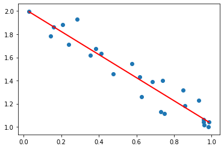

Note that Python's scipy and sklearn have their own methods for fitting a linear regression model instead of using our the function **linear_regression()** we created above. In scipy you may use **linregress()** (module: **scipy.stats**), and in sklearn the method is **LinearRegression()** (module: **sklearn.linear_model**). Examples of their usage are shown below.

```python
#alternatively (scipy):
from scipy.stats import linregress
beta1_pred, beta0_pred, _, _, _ = linregress(X, y)

#alternatively (sklearn):
from sklearn.linear_model import LinearRegression
model = LinearRegression().fit(X.reshape(-1,1), y)
beta1_pred, beta0_pred = model.coef_, model.intercept_
y_pred = model.predict(X_test.reshape(-1,1))
```

**Exercise 2**. Generate datasets of sizes $[5,10,20,50,100]$ as in the previous exercise. Repeat this 10 times in a for loop and store the parameter estimates $\widehat{\beta}_0$ and $\widehat{\beta}_1$. Create an error bar plot of the mean and standard deviation of these estimates.

How does the variance in the coefficient estimates change with dataset size? Would you recommend using small or large datasets for performing regression? Change $\sigma$ to 0.01 (not much noise) and then to 1 (a lot of noise), and note the change in the plots. What is the apparent effect of noise on regression?

## Regression Quality

It was mentioned in the lecture notes that beginning from the identity:

$$ y_i - \widehat{y}_i = (y_i - \overline{y}_i) - (\widehat{y}_i - \overline{y}_i)$$

the following may be derived:

$$\sum_i (y_i - \overline{y}_i)^2 = \sum_i (\widehat{y}_i - \overline{y}_i)^2 + \sum_i (y_i - \widehat{y}_i)^2 $$

We may then assess the quality of regression by evaluating the ratio $R^2$ consisting of dividing the first *RHS* term in the above equation by the *LHS* term. A ratio close to 1 is indicative of a linear trend or non-zero slope in the data.

**Exercise 3**. Generate a dataset as in the previous exercise consisting of 25 objects, $\sigma = 0.1$, $\beta_0 = 2$, and $\beta_1 = -1$. Compute the coefficient estimates and the ratio $R^2$(`*`). What can you deduce from this? Now set $\beta_1$ to vary beteen -1 and 1 in equally-spaced steps, and generate as much datasets. Estimate the regression coefficients for each dataset. Repeat this 10 times and create an error bar plot of $R^2$ versus $\beta_1$. What do you observe?

(`*`) Note: you may follow the equations above or you may use **sklearn.linear_model.LinearRegression()** in which case the model has an attribute called **score()** that return $R^2$, or you may use **scipy.stats.linregress()** which is the most concise.

```python
#scipy
from scipy.stats import linregress
beta1_pred, beta0_pred, r_value, p_value, std_err = linregress(X, y)
R_sq = r_value**2

#scikit-learn
from sklearn.linear_model import LinearRegression
model = LinearRegression().fit(X.reshape(-1,1), y)
beta1_pred = model.coef_
beta0_pred = model.intercept_
y_pred = model.predict(X_test.reshape(-1,1))
R_sq = model.score(X.reshape(-1,1), y)
```

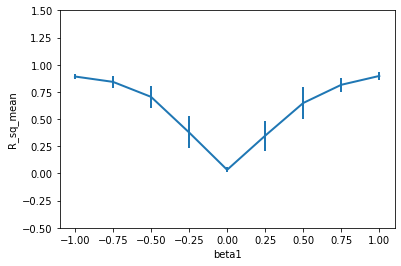

## Nonlinear Regression

In this section, we explore kernel regression as a form of local weighted regression.

**Exercise 4**. The function **kernel_regression()** is provided below. The function takes as input the training set abscissa values `X_train` and ordinate values `y_train`, a test set input `X_test`, and kernel width `h`. The output of the function is a set of regression predictions `y_pred`. For every test object or query point `q`, **kernel_regression()** gives a kernel smoothed output by weighing training set objects with a kernel function `K()` as follows:

$$\widehat{y}(q) = \dfrac{\sum_i K \left( \dfrac{x_i-q}{h} \right) y_i}{\sum_i K \left( \dfrac{x_i-q}{h} \right)}$$

The kernel function employed by **kernel_regression()** is a Gaussian kernel with kernel width `h` representing the standard deviation.

```python
def kernel_regression(X_train, y_train, X_test, h): #1D case
    y_pred = []
    for i in range(len(X_test)):
        K = np.exp(-(X_train-X_test[i])**2/h**2)
        y_pred.append((K*y_train).sum()/np.sum(K))
    return y_pred
```

Use the provided function **synth_data()** to generate a training dataset with $n=50$ objects and noise level $\sigma=0.1$.

```python
def synth_data(n_samples, sigma):
    X = np.random.uniform(low=0,high=1,size=n_samples)
    y = np.sin(4*X) + np.random.normal(loc=0,scale=sigma,size=n_samples)
    return X, y
```

Plot the data and generate a test set: **X_test = np.arange(0,1,0.01)**. Use the function **kernel_regression()** with kernel width $h=0.1$ to compute the regression predictions for the test set, and finally plot these using a different color onto the same plot. What happens near the boundary points? (this is known as boundary bias). Try different kernel widths, e.g. $h = [0.01, 0.05, 0.1, 0.2, 0.3]$. In your opinion, what is a good value for $h$? When does overfitting or underfitting occur?

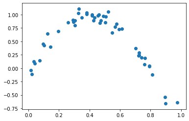

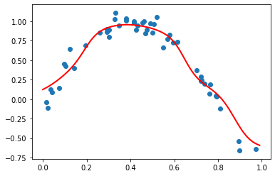

**Exercise 5**. In the previous exercise, we were able to generate a test set. However, in practice we often have only a single dataset to work with. Furthermore, we need to obtain a suitable value for the kernel width $h$ in an objective manner using only the given dataset. Therefore, ideally we should split the dataset into a training set and a test set, and then train our kernel regression model using the training set and see how it performs on the test set. We finally repeat the process several times for randomly drawn training sets and test sets and for different values of $h$. The optimal value of $h$ is that which yields the lowest test error. Use the provided function **optimize_h()** to perform all these steps. You only need to generate 50 objects using **synth_data()** and specify a range of kernel widths $h = [0.01, 0.05, 0.1, 0.2, 0.3]$. The output will be an errorbar plot of mean and standard deviation values of the mean square error (MSE) as a function of kernel width $h$. Which value of $h$ seems optimal? Why does the error increase for lower and higher values of $h$?

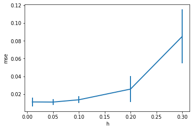

```python
def optimize_h(X, y, h):  #1D case
    from sklearn.model_selection import train_test_split
    rep = 5
    mse = np.zeros([rep,len(h)])
    for j, bandwidth in enumerate(h):
        for i in range(5):
            X_train, X_test, y_train, y_test = train_test_split(X, y, test_size=0.2)
            y_pred = kernel_regression(X_train, y_train, X_test, bandwidth)
            mse[i,j] = ((y_pred - y_test)**2).mean()
    plt.errorbar(h, mse.mean(axis=0), mse.std(axis=0), linewidth=2)
    plt.xlabel('h')
    plt.ylabel('mse')
    plt.show()
```

## Ridge regression

Next we explore ridge regression and observe how coefficients shrink when increasing the regularization parameter.

**Exercise 6**. Read in the file 'prostate.txt' which consists of 8 predictor variables and a target variable (antigen level). The last column indicates which data points should be included in the training set. Compute the correlation matrix using the full dataset (hint: **corr()** from pandas, or **corrcoef()** from numpy), but make sure not to include the last (indicator) column. Visualize the matrix using a heatmap. Which predictor variables seem to be mostly correlated with the target variable?

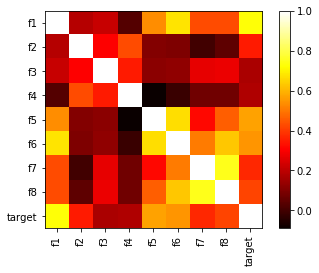

**Exercise 7**. We will apply ridge regression on the prostate dataset. Recall that coefficients are given by the following closed-form solution:

$$\widehat{{\beta}}_{ridge} = (\textbf{X}^T \textbf{X} + \lambda \textbf{I})^{-1} \textbf{X}^T \textbf{y}$$

These coefficients do not include the offset $\widehat{\beta}_0$ which can be computed as the mean of the target variable $\textbf{y}$. To apply the above equation, $\textbf{X}$ should consist of the training set with 8 features, i.e. the dimensions of matrix $\textbf{X}$ are $67 \times 8$. Moreover, before applying the equation, $\textbf{X}$ should be normalized by removing the mean and dividing by the standard deviation for each feature. The target variable $\textbf{y}$ should only have its mean removed. Select a range of values for the penalty term $\lambda$ as follows: $\lambda = [0.1,1,10,20,50,100,200,500,1000,2000,5000,10000]$. Looping over the values of $\lambda$, solve for the 8 coefficients for each value of $\lambda$. Finally, generate a plot showing how these coefficients shrink to zero as $\lambda$ increases. Note: use the `log10` of $\lambda$ on the x-axis.

Hint: if `X` below is the normalized version, the the above equations can be implemented as follows:

```python
n, p = X.shape
L = [0.1,1,10,20,50,100,200,500,1000,2000,5000,10000]

list_beta = [np.linalg.inv(X.T.dot(X) + np.identity(p)*l).dot(X.T).dot(y-y.mean()) for l in L]
beta = np.array(list_beta)

#create plot ...
```

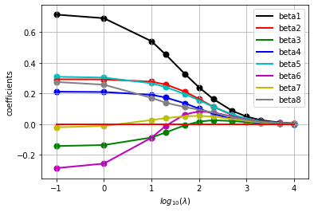

**Exercise 8**. As an alternative to plotting the coefficients as a function of $\lambda$ using a line plot, generate a heatmap revealing the same information stored in the ndarray of coefficients `beta`.

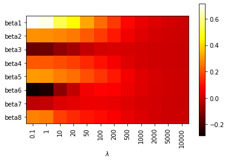